# UTS 37010 Assessment Task 1: Assignment Part A

Franklin Kipkorir

2025-03-31

# Question 1: Some Maths [12 marks]

## (a) Chi-squared and Confidence Interval [3 marks]

Given $X_i \sim \mathcal{N}(\mu, \sigma^2)$ for $i = 1, 2, \dots, n$, and $S^2$ is the sample variance, the test statistic

$$\frac{(n-1)S^2}{\sigma^2} \sim \chi^2(n-1)$$

To construct a one-sided $95\%$ confidence interval to test $H_0: \sigma^2 \geq c$ versus $H_A: \sigma^2 < c$, use

$$P\left( \sigma^2 > \frac{(n-1)S^2}{\chi^2_{1-\alpha, n-1}} \right) =
\alpha$$

So the lower bound for $\sigma^2$ is

$$\sigma^2 > \frac{(n-1)S^2}{\chi^2_{0.95, n-1}}$$

## (b) Covariance of Least Squares Estimators $\hat{\alpha}_i$ [3 marks]

Consider the model

$$Y_{ij} = \mu + \alpha_i + \epsilon_{ij}, \quad i \in \{1, \dots, a\}, \;
j \in \{1, \dots, n\}$$

with $\epsilon_{ij} \sim \mathcal{N}(0, \sigma^2)$. Then the least squares estimators are

$$\hat{\alpha}_i = \bar{Y}_i - \bar{Y}$$

Using ANOVA theory under the constraint $\sum \alpha_i = 0$, we have

$$\text{Cov}(\hat{\alpha}_i, \hat{\alpha}_j) = -\frac{\sigma^2}{an}, \quad
i \neq j$$

## (c) Least Squares Estimator in Log-linear Model [3 marks]

Given the model

$$e^{Y_i} = \beta x_i e^{\epsilon_i}, \quad \beta, x_i > 0, \;
\epsilon_i \sim \mathcal{N}(0, \sigma^2)$$

Take logs

$$Y_i = \log(\beta) + \log(x_i) + \epsilon_i$$

Then the transformed model is

$$\tilde{Y}_i = Y_i - \log(x_i) = \log(\beta) + \epsilon_i$$

By least squares

$$\log(\hat{\beta}) = \bar{Y} - \frac{1}{n} \sum_{i=1}^n \log(x_i)$$

Exponentiate both sides

$$\hat{\beta} = e^{\bar{Y}} \prod_{i=1}^n x_i^{-1/n}$$

Which simplifies to

$$\hat{\beta} = e^{\bar{Y}} \prod_{i=1}^n \left( \frac{1}{x_i}
\right)^{1/n}$$

## (d) Bias of Estimator $\hat{\beta}$ [3 marks]

We examine if $\hat{\beta}$ is unbiased

$$\hat{\beta} = \exp(\bar{Y}) \prod_{i=1}^n x_i^{-1/n}$$

Recall

$$Y_i = \log(\beta) + \log(x_i) + \epsilon_i \Rightarrow \bar{Y} =
\log(\beta) + \frac{1}{n} \sum \log(x_i) + \bar{\epsilon}$$

So

$$\hat{\beta} = \beta \cdot \exp(\bar{\epsilon})$$

Since $\bar{\epsilon} \sim \mathcal{N}(0, \sigma^2/n)$, use the MGF

$$E[\exp(\bar{\epsilon})] = \exp\left( \frac{\sigma^2}{2n} \right)$$

Hence

$$E[\hat{\beta}] = \beta \cdot \exp\left( \frac{\sigma^2}{2n} \right) \neq
\beta$$

So $\hat{\beta}$ is a **biased** estimator of $\beta$.

# Question 2: One and two-sample analysis [12 marks]

## (a) Histogram and normal curve [3 marks]

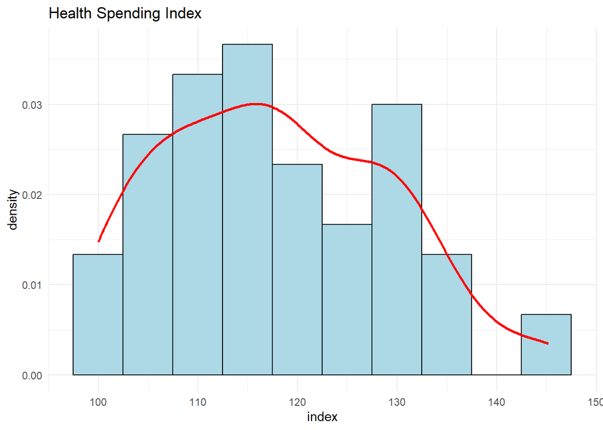

The histogram is moderately symmetric but with some slight right skew. The red density curve does not perfectly match a bell shape, suggesting mild deviations from normality, but the sample appears roughly normal for the purposes of t-tests.

## (b) One-sample t-test (Is mean $\neq 125$?) [3 marks]

```
##
##  One Sample t-test
##
## data:  health_data$index
## t = -4.8314, df = 59, p-value = 1.003e-05
## alternative hypothesis: true mean is not equal to 125
## 95 percent confidence interval:
##  115.0513 120.8787
## sample estimates:
## mean of x
##   117.965
```

**Hypotheses**: $H_0: \mu = 125$ - $H_A: \mu \neq 125$

**Decision**: The p-value = 1.003e-05 is less than 0.05, so we reject $H_0$.

**Conclusion**: There is strong evidence that the mean health spending index is significantly different from 125.

## (c) Two-sample t-test between time periods [3 marks]

```
##
##  Welch Two Sample t-test
##
## data:  july2021_dec2023 and jan2019_june2021
## t = 0.94188, df = 57.574, p-value = 0.1751
## alternative hypothesis: true difference in means is greater than 15
## 95 percent confidence interval:
##  13.58709      Inf
## sample estimates:
## mean of x mean of y
##  126.3767  109.5533
```

**Hypotheses**: $H_0: \mu_1 - \mu_2 \leq 15$ - $H_A: \mu_1 - \mu_2 > 15$

**Decision**: The p-value = 0.1751 is greater than 0.05, so we do not reject $H_0$.

**Conclusion**: There is insufficient evidence that the health spending index increased by more than 15 units between the two periods.

## (d) F-test for variance (Food vs Alcohol & Tobacco) [3 marks]

```
##
##  F test to compare two variances
##
## data:  food_index and alco_index
## F = 0.53075, num df = 59, denom df = 59, p-value = 0.008134
## alternative hypothesis: true ratio of variances is less than 1
## 95 percent confidence interval:
##  0.0000000 0.8173311
## sample estimates:
## ratio of variances
##          0.5307495
```

**Hypotheses**: $H_0: \sigma^2_{\text{food}} = \sigma^2_{\text{alco}}$ - $H_A: \sigma^2_{\text{food}} < \sigma^2_{\text{alco}}$

**Decision**: The p-value = 0.008134 is less than 0.05, so we reject $H_0$.

**Conclusion**: There is strong evidence that the variance in food spending is less than the variance in alcohol and tobacco spending.

# Question 3: Four-sample analysis [12 marks]

## (a) Residuals for category 3 [3 marks]

From the ANOVA model
$$Y_{ij} = \mu + \alpha_i + \epsilon_{ij}$$

To find residuals $\hat{\epsilon}_{3j}$ without fitting the model: 1. Compute the overall mean $\bar{Y}$ 2. Compute the group mean for category 3 $\bar{Y}_3$ 3. Estimate treatment effect $\hat{\alpha}_3 = \bar{Y}_3 - \bar{Y}$ 4. Residuals: $\hat{\epsilon}_{3j} = Y_{3j} - \bar{Y}_3$

These are deviations from category 3’s own group mean.

```
## [1] 277.0151
```

**Result**: Sample variance of residuals = **277.02**, reflecting variability within category 3.

## (b) One-way ANOVA test for any mean difference [3 marks]

```
##                   Df Sum Sq Mean Sq F value   Pr(>F)
## factor(category)   3   9522    3174   15.83 2.06e-09 ***
## Residuals        236  47306     200
## ---
## Signif. codes:  0 '***' 0.001 '**' 0.01 '*' 0.05 '.' 0.1 ' ' 1
```

**ANOVA Output** - F = 15.83, p-value = 2.06e-09

**Hypotheses** $H_0$: All group means are equal  
$H_A$: At least one group mean is different

**Decision**: Reject $H_0$ (p < 0.05)

**Conclusion**: Significant evidence that at least one group’s spending index mean is different.

## (c) Multiple comparisons to identify differing groups [3 marks]

```
##   Tukey multiple comparisons of means
##     95% family-wise confidence level
##
## Fit: aov(formula = index ~ factor(category), data = data)
##
## $`factor(category)`
##           diff        lwr        upr     p adj
## 2-1  -7.233333 -13.921567 -0.5450996 0.0282732
## 3-1  10.190000   3.501766 16.8782337 0.0006128
## 4-1  -1.710000  -8.398234  4.9782337 0.9113847
## 3-2  17.423333  10.735100 24.1115670 0.0000000
## 4-2   5.523333  -1.164900 12.2115670 0.1445481
## 4-3 -11.900000 -18.588234 -5.2117663 0.0000400
```

**Significant Differences** - 3 vs 1, 3 vs 2, and 4 vs 3 (p < 0.001) - 2 vs 1 (p = 0.028) is marginally significant - 4 vs 1 and 4 vs 2 are **not** significant

**Conclusion**: Category 3 is significantly different from others, particularly categories 1 and 2.

## (d) Normality of residuals [3 marks]

```
##
##  Shapiro-Wilk normality test
##
## data:  resid_vals
## W = 0.96977, p-value = 5.494e-05
```

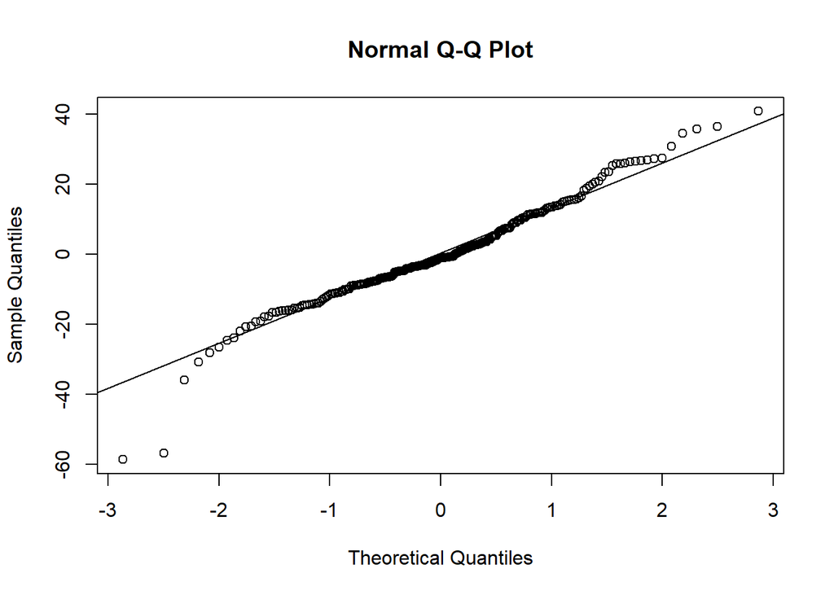

**Shapiro-Wilk Test Result** W = 0.96977, p-value = 5.494e-05

**Hypotheses** $H_0$: Residuals are normally distributed  
$H_A$: Residuals are not normally distributed

**Decision**: Reject $H_0$ (p < 0.05)

**Conclusion**: Residuals are **not normally distributed**, supported by both a low p-value and visible deviations from the normal line in the Q-Q plot.

# Question 4: Linear regression [18 marks]

## (a) Variance inflation factor (VIF) for multicollinearity [3 marks]

```
##   index2   index3
## 1.023089 1.023089
```

**Interpretation**: VIF values were: - index2: **1.023** - index3: **1.023**

Both are well below 5, suggesting no multicollinearity concern.

## (b) Fit the model and write regression equation [3 marks]

```
##
## Call:
## lm(formula = index1 ~ index2 + index3, data = wide_data)
##
## Residuals:
##      Min       1Q   Median       3Q      Max
## -11.0317  -4.6274   0.4186   3.0628  18.8968
##
## Coefficients:
##             Estimate Std. Error t value Pr(>|t|)
## (Intercept) 12.40676    8.83378   1.404    0.166
## index2       0.48704    0.06582   7.400 6.86e-10 ***
## index3       0.40285    0.04795   8.401 1.49e-11 ***
## ---
## Signif. codes:  0 '***' 0.001 '**' 0.01 '*' 0.05 '.' 0.1 ' ' 1
##
## Residual standard error: 6.061 on 57 degrees of freedom
## Multiple R-squared:  0.7211, Adjusted R-squared:  0.7113
## F-statistic: 73.67 on 2 and 57 DF,  p-value: < 2.2e-16
```

**Estimated equation**
$$\hat{\text{Health}} = 12.41 + 0.487\cdot \text{Alcohol} + 0.403\cdot
\text{Food}$$

Model fit: Adjusted R² = **0.711**, F(2,57) = **73.67**, p < 0.001.

## (c) Hypothesis test: Does alcohol index decrease health? [3 marks]

```
##                  2.5 %     97.5 %
## (Intercept) -5.2825810 30.0960935
## index2       0.3552412  0.6188393
## index3       0.3068328  0.4988707
```

**Hypotheses**: $H_0: \beta_1 \leq -0.3$ - $H_A: \beta_1 > -0.3$

95% CI for $\beta_1$: (0.355, 0.619). Since the entire interval is > -0.3, we **reject** $H_0$.

**Conclusion**: There is strong evidence that an increase in alcohol index is associated with more than a 0.3 unit **increase**, not decrease, in health index.

## (d) Diagnostic plots to assess regression assumptions [3 marks]

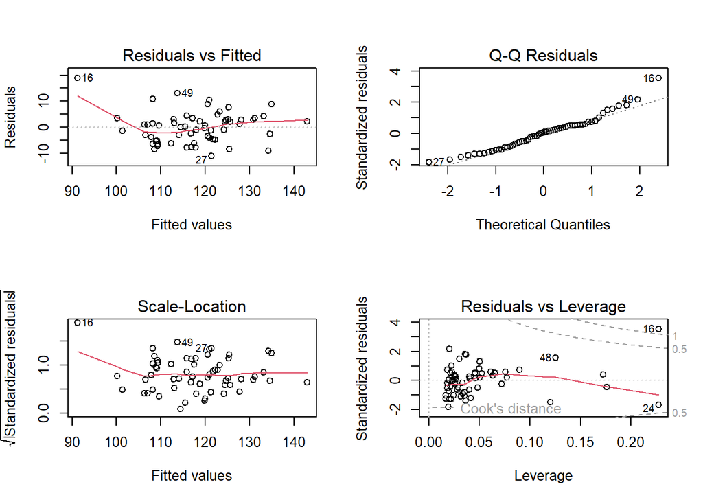

**Assessment**: - **Linearity**: Some curve in Residuals vs Fitted → mild non-linearity - **Normality**: Q-Q plot shows slight deviation at tails - **Homoscedasticity**: Scale-Location plot is fairly level - **Influence**: Observations 16, 48, 24 show high leverage (see Cook’s D)

Assumptions mostly hold but should monitor influential points.

## (e) Test for independence of residuals [3 marks]

```
##
##  Durbin-Watson test
##
## data:  fit
## DW = 0.96084, p-value = 3.419e-06
## alternative hypothesis: true autocorrelation is greater than 0
```

**Durbin-Watson test**: - DW = 0.961, p = 3.42e-06 → **Reject** $H_0$

**Conclusion**: Residuals are **autocorrelated**, violating independence assumption. Inference from regression may be biased.

## (f) Influence analysis and refitting [3 marks]

```
##
## Call:
## lm(formula = index1 ~ index2 + index3, data = wide_data[-influential_points,
##     ])
##
## Residuals:
##      Min       1Q   Median       3Q      Max
## -11.2697  -3.9651   0.4319   2.7681  13.9270
##
## Coefficients:
##             Estimate Std. Error t value Pr(>|t|)
## (Intercept) -2.85307    8.54867  -0.334     0.74
## index2       0.53646    0.06498   8.256 3.35e-11 ***
## index3       0.47743    0.04799   9.949 6.71e-14 ***
## ---
## Signif. codes:  0 '***' 0.001 '**' 0.01 '*' 0.05 '.' 0.1 ' ' 1
##
## Residual standard error: 5.316 on 55 degrees of freedom
## Multiple R-squared:  0.7897, Adjusted R-squared:  0.782
## F-statistic: 103.3 on 2 and 55 DF,  p-value: < 2.2e-16
```

**Updated regression** (excluding points 16 and 48):
$$\hat{\text{Health}} = -2.85 + 0.536\cdot
\text{Alcohol} + 0.477\cdot \text{Food}$$

**Model improvement**: - Adjusted R² increased from **0.711** → **0.782** - Standard error reduced from 6.06 → **5.32**

**Conclusion**: Excluding influential points improved model fit and increased the estimated impact of both predictors.

## References

- Lecture Notes: *37010 Statistics Chapter 3* (Scott Alexander, UTS)
- R Documentation: `aov()`, `TukeyHSD()`, `shapiro.test()`